# Project: Investigate a Dataset - No-show appointments

- Introduction
- Data Wrangling
- Exploratory Data Analysis
- Conclusions

## Introduction

### Dataset Description

This dataset collects information from 100k medical appointments in Brazil and is focused on the question of whether or not patients show up for their appointment. A number of characteristics about the patient are included in each row. This dataset is originally taken from [Kaggle](https://www.kaggle.com/datasets/joniarroba/noshowappointments).

### Dataset Columns

#### PatientId

- Identification of a patient.

#### AppointmentID

- Identification of each appointment.

#### Gender

- Male or Female.

#### ScheduledDay

- The day the patient set up their appointment.

#### AppointmentDay

- The actual day of the appointment.

#### Age

- How old the patient is.

#### Neighbourhood

- The location of the hospital.

#### Scholarship

- True of False. Whether or not the patient is enrolled in Brasilian welfare program Bolsa Família.

#### Hipertension

- True or False

#### Diabetes

- True or False

#### Alcoholism

- True or False

#### Handcap

- True or False

#### SMS_received

- 1 or more messages sent to the patient.

#### No-show

- 'Yes' or 'No'. 'Yes' means the patient did not come, while 'No' means that the patient visited the doctor on the appointment day.

### Question(s) for Analysis

The factors that are important for us to know in which cases patients will not visit the scheduled appointment:

1. Which age and gender groups had the most number of 'No-show' cases?
2. Which locations had the most number of 'No-show' cases?
3. People suffering from which illness had the most number of 'No-show' cases?
4. Do the appointment days have an impact on the number of 'No-show' cases?

```python
#import packages
import pandas as pd
import matplotlib.pyplot as plt
import numpy as np
import seaborn as sns
%matplotlib inline
```

```python
# Upgrade pandas to use dataframe.explode() function.
# !pip install --upgrade pandas==1.1.5
```

## Data Wrangling

### General Properties

```python
# load the dataset
df = pd.read_csv("noshowappointments-kagglev2-may-2016.csv")
```

```python
# see the first few lines
df.head()
```

|  | PatientId | AppointmentID | Gender | ScheduledDay | AppointmentDay | Age | Neighbourhood | Scholarship | Hipertension | Diabetes | Alcoholism | Handcap | SMS_received | No-show |
| --- | --- | --- | --- | --- | --- | --- | --- | --- | --- | --- | --- | --- | --- | --- |
| 0 | 2.987250e+13 | 5642903 | F | 2016-04-29T18:38:08Z | 2016-04-29T00:00:00Z | 62 | JARDIM DA PENHA | 0 | 1 | 0 | 0 | 0 | 0 | No |
| 1 | 5.589978e+14 | 5642503 | M | 2016-04-29T16:08:27Z | 2016-04-29T00:00:00Z | 56 | JARDIM DA PENHA | 0 | 0 | 0 | 0 | 0 | 0 | No |
| 2 | 4.262962e+12 | 5642549 | F | 2016-04-29T16:19:04Z | 2016-04-29T00:00:00Z | 62 | MATA DA PRAIA | 0 | 0 | 0 | 0 | 0 | 0 | No |
| 3 | 8.679512e+11 | 5642828 | F | 2016-04-29T17:29:31Z | 2016-04-29T00:00:00Z | 8 | PONTAL DE CAMBURI | 0 | 0 | 0 | 0 | 0 | 0 | No |
| 4 | 8.841186e+12 | 5642494 | F | 2016-04-29T16:07:23Z | 2016-04-29T00:00:00Z | 56 | JARDIM DA PENHA | 0 | 1 | 1 | 0 | 0 | 0 | No |

```python
# number of rows and columns
df.shape
```

```
(110527, 14)
```

```python
# check the data types and see if there are null values
df.info()
```

```
<class 'pandas.core.frame.DataFrame'>
RangeIndex: 110527 entries, 0 to 110526
Data columns (total 14 columns):
 #   Column          Non-Null Count   Dtype
---  ------          --------------   -----
 0   PatientId       110527 non-null  float64
 1   AppointmentID   110527 non-null  int64
 2   Gender          110527 non-null  object
 3   ScheduledDay    110527 non-null  object
 4   AppointmentDay  110527 non-null  object
 5   Age             110527 non-null  int64
 6   Neighbourhood   110527 non-null  object
 7   Scholarship     110527 non-null  int64
 8   Hipertension    110527 non-null  int64
 9   Diabetes        110527 non-null  int64
 10  Alcoholism      110527 non-null  int64
 11  Handcap         110527 non-null  int64
 12  SMS_received    110527 non-null  int64
 13  No-show         110527 non-null  object
dtypes: float64(1), int64(8), object(5)
memory usage: 11.8+ MB
```

```python
# get the descriptive statistics about the dataset
df.describe()
```

|  | PatientId | AppointmentID | Age | Scholarship | Hipertension | Diabetes | Alcoholism | Handcap | SMS_received |
| --- | --- | --- | --- | --- | --- | --- | --- | --- | --- |
| count | 1.105270e+05 | 1.105270e+05 | 110527.000000 | 110527.000000 | 110527.000000 | 110527.000000 | 110527.000000 | 110527.000000 | 110527.000000 |
| mean | 1.474963e+14 | 5.675305e+06 | 37.088874 | 0.098266 | 0.197246 | 0.071865 | 0.030400 | 0.022248 | 0.321026 |
| std | 2.560949e+14 | 7.129575e+04 | 23.110205 | 0.297675 | 0.397921 | 0.258265 | 0.171686 | 0.161543 | 0.466873 |
| min | 3.921784e+04 | 5.030230e+06 | -1.000000 | 0.000000 | 0.000000 | 0.000000 | 0.000000 | 0.000000 | 0.000000 |
| 25% | 4.172614e+12 | 5.640286e+06 | 18.000000 | 0.000000 | 0.000000 | 0.000000 | 0.000000 | 0.000000 | 0.000000 |
| 50% | 3.173184e+13 | 5.680573e+06 | 37.000000 | 0.000000 | 0.000000 | 0.000000 | 0.000000 | 0.000000 | 0.000000 |
| 75% | 9.439172e+13 | 5.725524e+06 | 55.000000 | 0.000000 | 0.000000 | 0.000000 | 0.000000 | 0.000000 | 1.000000 |
| max | 9.999816e+14 | 5.790484e+06 | 115.000000 | 1.000000 | 1.000000 | 1.000000 | 1.000000 | 4.000000 | 1.000000 |

There seems to be issues with the values of the **Age** and **Handcap** columns. The minimum age cannot be -1. **Handcap** column was also said to contain either *true* or *false* values. We will address these issues in the data cleaning section.

### Data Cleaning

#### Modify the data types

We have seen the problems with the data types of the **ScheduledDay** and **AppointmentDay** columns. We change them to **datetime** from **string**.

```python
# convert the data types to datetime
df['ScheduledDay'] = pd.to_datetime(df['ScheduledDay'])
df['AppointmentDay'] = pd.to_datetime(df['AppointmentDay'])
```

```python
# check if the changes are applied
df.info()
```

```
<class 'pandas.core.frame.DataFrame'>
RangeIndex: 110527 entries, 0 to 110526
Data columns (total 14 columns):
 #   Column          Non-Null Count   Dtype
---  ------          --------------   -----
 0   PatientId       110527 non-null  float64
 1   AppointmentID   110527 non-null  int64
 2   Gender          110527 non-null  object
 3   ScheduledDay    110527 non-null  datetime64[ns, UTC]
 4   AppointmentDay  110527 non-null  datetime64[ns, UTC]
 5   Age             110527 non-null  int64
 6   Neighbourhood   110527 non-null  object
 7   Scholarship     110527 non-null  int64
 8   Hipertension    110527 non-null  int64
 9   Diabetes        110527 non-null  int64
 10  Alcoholism      110527 non-null  int64
 11  Handcap         110527 non-null  int64
 12  SMS_received    110527 non-null  int64
 13  No-show         110527 non-null  object
dtypes: datetime64[ns, UTC](2), float64(1), int64(8), object(3)
memory usage: 11.8+ MB
```

#### Fix the issues with Age and Handcap columns

Let us see which rows have the values below 0 for the **Age** column.

```python
below_zero = df.query('Age < 0')
below_zero
```

|  | PatientId | AppointmentID | Gender | ScheduledDay | AppointmentDay | Age | Neighbourhood | Scholarship | Hipertension | Diabetes | Alcoholism | Handcap | SMS_received | No-show |
| --- | --- | --- | --- | --- | --- | --- | --- | --- | --- | --- | --- | --- | --- | --- |
| 99832 | 4.659432e+14 | 5775010 | F | 2016-06-06 08:58:13+00:00 | 2016-06-06 00:00:00+00:00 | -1 | ROMÃO | 0 | 0 | 0 | 0 | 0 | 0 | No |

We can drop this row as having this age is unrealistic. There must have been a typo.

```python
# drop the row by using its index
df.drop(below_zero.index, inplace=True)
```

```python
# check if the changes are successful
df.query('Age < 0')
```

|  | PatientId | AppointmentID | Gender | ScheduledDay | AppointmentDay | Age | Neighbourhood | Scholarship | Hipertension | Diabetes | Alcoholism | Handcap | SMS_received | No-show |
| --- | --- | --- | --- | --- | --- | --- | --- | --- | --- | --- | --- | --- | --- | --- |

We check the unique values of the **Handcap** column. They should be either 0 or 1 according to the dataset description.

```python
df['Handcap'].unique()
```

```
array([0, 1, 2, 3, 4])
```

```python
df.groupby('Handcap').count()
```

| Handcap | PatientId | AppointmentID | Gender | ScheduledDay | AppointmentDay | Age | Neighbourhood | Scholarship | Hipertension | Diabetes | Alcoholism | SMS_received | No-show |
| --- | --- | --- | --- | --- | --- | --- | --- | --- | --- | --- | --- | --- | --- |
| 0 | 108285 | 108285 | 108285 | 108285 | 108285 | 108285 | 108285 | 108285 | 108285 | 108285 | 108285 | 108285 | 108285 |
| 1 | 2042 | 2042 | 2042 | 2042 | 2042 | 2042 | 2042 | 2042 | 2042 | 2042 | 2042 | 2042 | 2042 |
| 2 | 183 | 183 | 183 | 183 | 183 | 183 | 183 | 183 | 183 | 183 | 183 | 183 | 183 |
| 3 | 13 | 13 | 13 | 13 | 13 | 13 | 13 | 13 | 13 | 13 | 13 | 13 | 13 |
| 4 | 3 | 3 | 3 | 3 | 3 | 3 | 3 | 3 | 3 | 3 | 3 | 3 | 3 |

It looks like the values are given according to the level of handicap severeness as there are a lot of rows with the values larger than 1. Since we are only interested whether the patient has disabilities or not, we can replace the values larger than 1 with 1, which indicates *true*.

```python
# apply lambda function to replace the values
df['Handcap'] = df['Handcap'].apply(lambda x: 1 if x >= 1 else 0)
```

```python
# check if the values are 0 and 1
df['Handcap'].unique()
```

```
array([0, 1])
```

```python
df.groupby('Handcap').count()
```

| Handcap | PatientId | AppointmentID | Gender | ScheduledDay | AppointmentDay | Age | Neighbourhood | Scholarship | Hipertension | Diabetes | Alcoholism | SMS_received | No-show |
| --- | --- | --- | --- | --- | --- | --- | --- | --- | --- | --- | --- | --- | --- |
| 0 | 108285 | 108285 | 108285 | 108285 | 108285 | 108285 | 108285 | 108285 | 108285 | 108285 | 108285 | 108285 | 108285 |
| 1 | 2241 | 2241 | 2241 | 2241 | 2241 | 2241 | 2241 | 2241 | 2241 | 2241 | 2241 | 2241 | 2241 |

```python
# check the values of other columns too
print(df['No-show'].unique())
print(df['Gender'].unique())
```

```
['No' 'Yes']
['F' 'M']
```

We also need to rename some of the column names for better analysis

```python
df.rename(columns={'No-show': 'No_show'}, inplace=True)
df.sample(1)
```

|  | PatientId | AppointmentID | Gender | ScheduledDay | AppointmentDay | Age | Neighbourhood | Scholarship | Hipertension | Diabetes | Alcoholism | Handcap | SMS_received | No_show |
| --- | --- | --- | --- | --- | --- | --- | --- | --- | --- | --- | --- | --- | --- | --- |
| 105858 | 4.567163e+13 | 5781813 | F | 2016-06-07 10:03:22+00:00 | 2016-06-07 00:00:00+00:00 | 27 | TABUAZEIRO | 0 | 0 | 0 | 0 | 0 | 0 | No |

## Exploratory Data Analysis

### 1. Which age and gender groups had the most number of 'No-show' cases?

Let us first see the percentages of patients who visited the hospital or not using the pie chart.

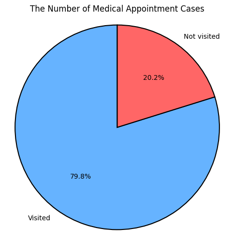

```python
# Create a figure and axis
fig, ax = plt.subplots(figsize=(6, 6))

# Prepare the data for pie chart
no_show_series = df['No_show'].value_counts()

# Define colors for the pie chart slices
colors = ['#66b3ff', '#ff6666']  # Light blue for "Visited", Light red for "Not visited"

# Plot the pie chart with customized options
ax.pie(no_show_series.values, labels=['Visited', 'Not visited'], autopct='%1.1f%%', startangle=90, colors=colors,
       wedgeprops={'edgecolor': 'black', 'linewidth': 1.5, 'linestyle': 'solid'})

# Add a title with custom font style and size
plt.title("The Number of Medical Appointment Cases")

# Show the plot
plt.axis('equal')  # Equal aspect ratio ensures that pie is drawn as a circle.
plt.show()
```

Now we analyse the "No-show" cases in more details.

```python
# Extract only the 'No-show' cases for further analysis
df_no_show = df.query('No_show == "Yes"')
```

#### Bar chart to see the distribution of 'No-show' cases

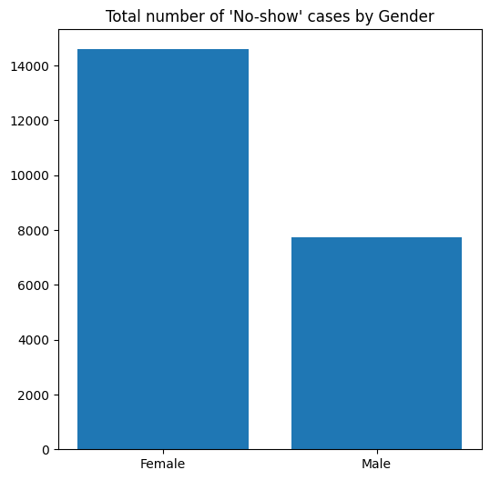

```python
# Create a figure and axis
plt.figure(figsize=(6, 6))
no_show_gender = df_no_show['Gender'].value_counts()
plt.title("Total number of 'No-show' cases by Gender")
plt.bar(['Female', 'Male'], no_show_gender.values);
```

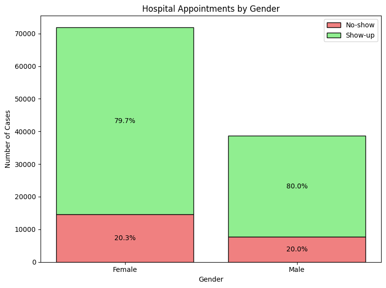

```python
# Calculate the Show-up cases by subtracting No-show cases from Total appointments
total_gender = df['Gender'].value_counts()
no_show_gender = df_no_show['Gender'].value_counts()
show_up_gender = total_gender - no_show_gender

# Calculate the percentage of No-show and Show-up cases
no_show_percentage_gender = (no_show_gender / total_gender) * 100
show_up_percentage_gender = (show_up_gender / total_gender) * 100

# Create the stacked bar plot
plt.figure(figsize=(8, 6))
plt.title("Hospital Appointments by Gender")
plt.xlabel("Gender")
plt.ylabel("Number of Cases")

# Stacked bar plot: No-show cases in red, Show-up cases in lightgreen
bars1 = plt.bar(['Female', 'Male'], no_show_gender, label='No-show', color='lightcoral', edgecolor='black')
bars2 = plt.bar(['Female', 'Male'], show_up_gender, bottom=no_show_gender, label='Show-up', color='lightgreen', edgecolor='black')

# Add percentage labels inside the bars
for i, (no_show, show_up, no_show_pct, show_up_pct) in enumerate(zip(no_show_gender, show_up_gender, no_show_percentage_gender, show_up_percentage_gender)):
    # No-show percentage label
    plt.text(i, no_show / 2, f'{no_show_pct:.1f}%', ha='center', va='center', fontsize=10, color='black')
    # Show-up percentage label
    plt.text(i, no_show + show_up / 2, f'{show_up_pct:.1f}%', ha='center', va='center', fontsize=10, color='black')

# Add legend
plt.legend()

# Show the plot
plt.tight_layout()
plt.show()
```

#### Histograms to illustrate the 'No-show' case distributions among age groups

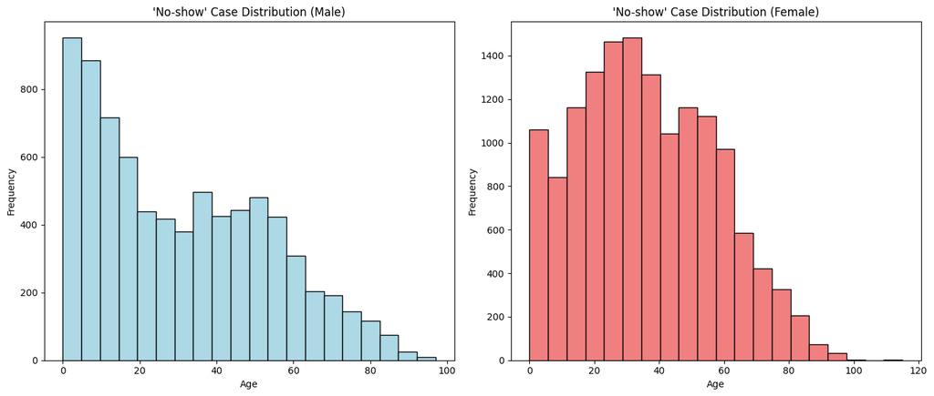

```python
# Create a figure and axis with two subplots (1 row, 2 columns)
fig, ax = plt.subplots(1, 2, figsize=(14, 6))

# Plot for Male 'No-show' case distributions
ax[0].hist(df_no_show.query('Gender == "M"')['Age'], bins=20, color='lightblue', edgecolor='black')
ax[0].set_title("'No-show' Case Distribution (Male)")
ax[0].set_xlabel("Age")
ax[0].set_ylabel("Frequency")

# Plot for Female 'No-show' case distributions
ax[1].hist(df_no_show.query('Gender == "F"')['Age'], bins=20, color='lightcoral', edgecolor='black')
ax[1].set_title("'No-show' Case Distribution (Female)")
ax[1].set_xlabel("Age")
ax[1].set_ylabel("Frequency")

# Adjust layout for better spacing between plots
plt.tight_layout()

# Show the plot
plt.show()
```

### 2. Which locations had the most number of 'No-show' cases?

```python
df_no_show['Neighbourhood'].value_counts().sort_values(ascending=False)[:10]
```

| Neighbourhood | count |
| --- | --- |
| JARDIM CAMBURI | 1465 |
| MARIA ORTIZ | 1219 |
| ITARARÉ | 923 |
| RESISTÊNCIA | 906 |
| CENTRO | 703 |
| JESUS DE NAZARETH | 696 |
| JARDIM DA PENHA | 631 |
| CARATOÍRA | 591 |
| TABUAZEIRO | 573 |
| BONFIM | 550 |

**dtype:** int64

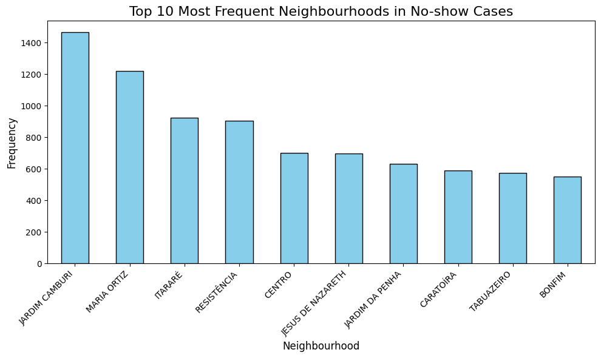

```python
# Get the top 10 neighborhoods based on the value counts
top_neighborhoods = df_no_show['Neighbourhood'].value_counts().sort_values(ascending=False)[:10]

# Create a bar plot
plt.figure(figsize=(10, 6))
top_neighborhoods.plot(kind='bar', color='skyblue', edgecolor='black')

# Add title and labels
plt.title('Top 10 Most Frequent Neighbourhoods in No-show Cases', fontsize=16)
plt.xlabel('Neighbourhood', fontsize=12)
plt.ylabel('Frequency', fontsize=12)

# Rotate x-axis labels for better readability
plt.xticks(rotation=45, ha='right')

# Show the plot
plt.tight_layout()
plt.show()
```

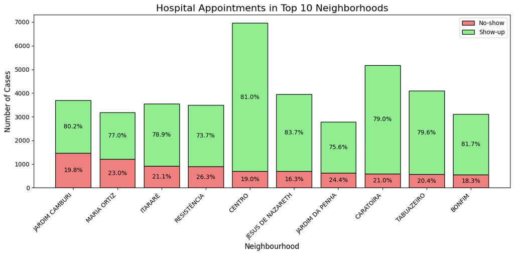

```python
# Get the top 10 neighborhoods based on the No-show value counts
top_neighborhoods_no_show = df_no_show['Neighbourhood'].value_counts().sort_values(ascending=False)[:10]

# Get the corresponding total cases for these neighborhoods
top_neighborhoods_total = df[df['Neighbourhood'].isin(top_neighborhoods_no_show.index)]['Neighbourhood'].value_counts()

# Calculate the Show-up cases
top_neighborhoods_show_up = top_neighborhoods_total - top_neighborhoods_no_show

# Calculate the percentages
no_show_percentage_neighborhood = (top_neighborhoods_no_show / top_neighborhoods_total) * 100
show_up_percentage_neighborhood = (top_neighborhoods_show_up / top_neighborhoods_total) * 100

# Create the stacked bar plot
plt.figure(figsize=(12, 6))
plt.title('Hospital Appointments in Top 10 Neighborhoods', fontsize=16)
plt.xlabel('Neighbourhood', fontsize=12)
plt.ylabel('Number of Cases', fontsize=12)

# Stacked bar plot: No-show cases in red, Show-up cases in lightgreen
bars1 = plt.bar(top_neighborhoods_no_show.index, top_neighborhoods_no_show, label='No-show', color='lightcoral', edgecolor='black')
bars2 = plt.bar(top_neighborhoods_no_show.index, top_neighborhoods_show_up, bottom=top_neighborhoods_no_show, label='Show-up', color='lightgreen', edgecolor='black')

# Add percentage labels inside the bars
for i, (no_show, show_up, no_show_pct, show_up_pct) in enumerate(zip(top_neighborhoods_no_show, top_neighborhoods_show_up, no_show_percentage_neighborhood, show_up_percentage_neighborhood)):
    # No-show percentage label
    plt.text(i, no_show / 2, f'{no_show_pct:.1f}%', ha='center', va='center', fontsize=10, color='black')
    # Show-up percentage label
    plt.text(i, no_show + show_up / 2, f'{show_up_pct:.1f}%', ha='center', va='center', fontsize=10, color='black')

# Rotate x-axis labels for better readability
plt.xticks(rotation=45, ha='right')

# Add legend
plt.legend()

# Show the plot
plt.tight_layout()
plt.show()
```

### 3. People suffering from which illness had the most number of 'No-show' cases?

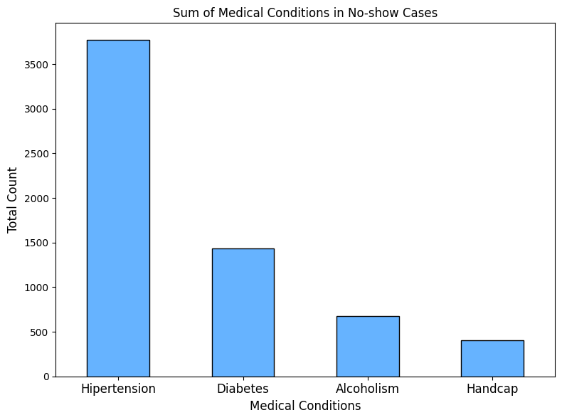

```python
# Calculate the sum of conditions and create the bar plot
condition_sums = df_no_show[['Hipertension', 'Diabetes', 'Alcoholism', 'Handcap']].sum()

# Create a bar plot with a single color
plt.figure(figsize=(8, 6))
condition_sums.plot(kind='bar', color='#66b3ff', edgecolor='black')

# Add title and labels
plt.title('Sum of Medical Conditions in No-show Cases')
plt.xlabel('Medical Conditions', fontsize=12)
plt.ylabel('Total Count', fontsize=12)

# Set x-axis labels and adjust the plot layout
plt.xticks(rotation=0, fontsize=12)
plt.tight_layout()

# Show the plot
plt.show()
```

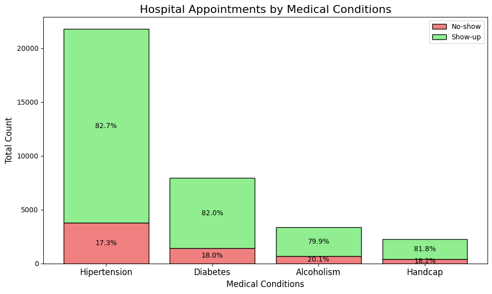

```python
# Calculate the sum of conditions for No-show and Total cases
no_show_condition_sums = df_no_show[['Hipertension', 'Diabetes', 'Alcoholism', 'Handcap']].sum()
total_condition_sums = df[['Hipertension', 'Diabetes', 'Alcoholism', 'Handcap']].sum()

# Calculate Show-up cases by subtracting No-show cases from Total cases
show_up_condition_sums = total_condition_sums - no_show_condition_sums

# Calculate the percentages
no_show_percentage_conditions = (no_show_condition_sums / total_condition_sums) * 100
show_up_percentage_conditions = (show_up_condition_sums / total_condition_sums) * 100

# Create the stacked bar plot
plt.figure(figsize=(10, 6))
plt.title('Hospital Appointments by Medical Conditions', fontsize=16)
plt.xlabel('Medical Conditions', fontsize=12)
plt.ylabel('Total Count', fontsize=12)

# Stacked bar plot: No-show cases in red, Show-up cases in lightgreen
bars1 = plt.bar(no_show_condition_sums.index, no_show_condition_sums, label='No-show', color='lightcoral', edgecolor='black')
bars2 = plt.bar(no_show_condition_sums.index, show_up_condition_sums, bottom=no_show_condition_sums, label='Show-up', color='lightgreen', edgecolor='black')

# Add percentage labels inside the bars
for i, (no_show, show_up, no_show_pct, show_up_pct) in enumerate(zip(no_show_condition_sums, show_up_condition_sums, no_show_percentage_conditions, show_up_percentage_conditions)):
    # No-show percentage label
    plt.text(i, no_show / 2, f'{no_show_pct:.1f}%', ha='center', va='center', fontsize=10, color='black')
    # Show-up percentage label
    plt.text(i, no_show + show_up / 2, f'{show_up_pct:.1f}%', ha='center', va='center', fontsize=10, color='black')

# Adjust the layout and x-axis labels
plt.xticks(rotation=0, fontsize=12)
plt.legend()

# Show the plot
plt.tight_layout()
plt.show()
```

### 4. Do the appointment days have an impact on the number of 'No-show' cases?

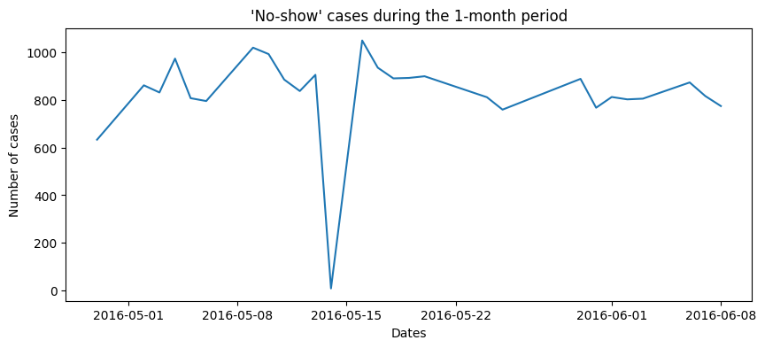

```python
# extracts dates and their counts
noshow_days = df_no_show.groupby('AppointmentDay')['No_show'].count()

# plot the results using the line chart
plt.figure(figsize=(10, 4))
plt.title("'No-show' cases during the 1-month period")
plt.xlabel("Dates")
plt.ylabel("Number of cases")
plt.plot(noshow_days.index, noshow_days.values);
```

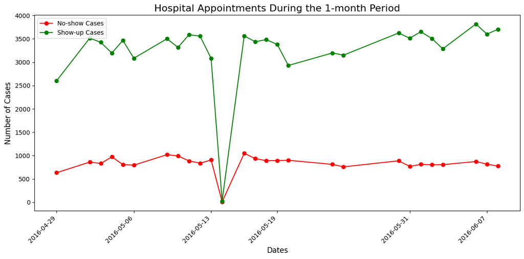

```python
# Extract counts for No-show and Total cases by AppointmentDay
noshow_days = df_no_show.groupby('AppointmentDay')['No_show'].count()
total_days = df.groupby('AppointmentDay')['No_show'].count()

# Calculate Show-up cases by subtracting No-show cases from Total cases
show_up_days = total_days - noshow_days

# Calculate percentages
no_show_percentage_days = (noshow_days / total_days) * 100
show_up_percentage_days = (show_up_days / total_days) * 100

# Create the line chart
plt.figure(figsize=(12, 6))
plt.title("Hospital Appointments During the 1-month Period", fontsize=16)
plt.xlabel("Dates", fontsize=12)
plt.ylabel("Number of Cases", fontsize=12)

# Plot No-show and Show-up cases
plt.plot(noshow_days.index, noshow_days, label='No-show Cases', color='red', linestyle='-', marker='o')
plt.plot(noshow_days.index, show_up_days, label='Show-up Cases', color='green', linestyle='-', marker='o')

# Add legends and labels
plt.xticks(noshow_days.index[::5], rotation=45, ha='right')  # Label only every 5th date for readability
plt.legend(loc='upper left')
plt.tight_layout()

# Show the plot
plt.show()
```

Interestingly, slightly before May 15, 2016 there were almost no 'No-show' cases. Let us find out which date this exactly is.

```python
noshow_days[noshow_days == noshow_days.min()]
```

| AppointmentDay | No_show |
| --- | --- |
| 2016-05-14 00:00:00+00:00 | 9 |

**dtype:** int64

Let us check the total visits on this day.

```python
df[df['AppointmentDay'] == '2016-05-14']['No_show'].value_counts()
```

| No_show | count |
| --- | --- |
| No | 30 |
| Yes | 9 |

**dtype:** int64

It looks like there were only 39 appointed visits on this day.

#### Analysis based on the day of the week

We can see from the line chart that there are more 'no-show' cases between similar periods of days. This leads us to analyse the dataset according to the days of the week.

```python
# add the new column with the name of the day of the week according to the corresponding date
df['AppointmentDay_week'] = df['AppointmentDay'].dt.dayofweek
```

```python
df_no_show.head(3)
```

[output not shown]

```python
# Ensure 'AppointmentDay_week' is a numeric representation of the day of the week
df_no_show['AppointmentDay_week'] = df_no_show['AppointmentDay'].dt.dayofweek
```

```python
# Days of the week
days_of_week = ['Monday', 'Tuesday', 'Wednesday', 'Thursday', 'Friday', 'Saturday']

# Get the total count of the no-show cases by the day of the week
noshow_weekdays = df_no_show['AppointmentDay_week'].value_counts().sort_index()
# Reindex to ensure all 7 days of the week are represented
# The 'range(7)' ensures we get all 7 days (0-6), and fill missing days with 0
noshow_weekdays = noshow_weekdays.reindex(range(6), fill_value=0)

# Map the index from numbers (0-6) to day names
noshow_weekdays.index = days_of_week

noshow_weekdays
```

|  | count |
| --- | --- |
| Monday | 4690 |
| Tuesday | 5152 |
| Wednesday | 5093 |
| Thursday | 3338 |
| Friday | 4037 |
| Saturday | 9 |

**dtype:** int64

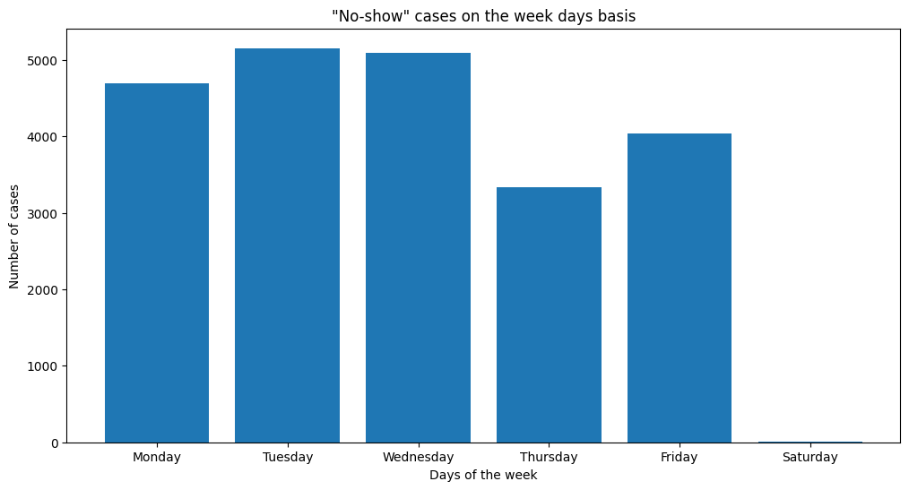

```python
labels = ['Monday', 'Tuesday', 'Wednesday', 'Thursday', 'Friday', 'Saturday']
plt.figure(figsize=(12, 6))
plt.title('"No-show" cases on the week days basis')
plt.xlabel('Days of the week')
plt.ylabel('Number of cases')
plt.bar(noshow_weekdays.index, noshow_weekdays.values, tick_label=labels);
```

Now it is clear that the date `2016-05-14` was Saturday when there were almost no visits, so the line chart had the sudden drop.

Let us compare the results with the entire dataset's scheduled appointment cases.

```python
# count the total scheduled appointments on the weekly basis
df_weekdays = df['AppointmentDay_week'].value_counts().sort_index()
df_weekdays
```

| AppointmentDay_week | count |
| --- | --- |
| 0 | 22714 |
| 1 | 25640 |
| 2 | 25867 |
| 3 | 17247 |
| 4 | 19019 |
| 5 | 39 |

**dtype:** int64

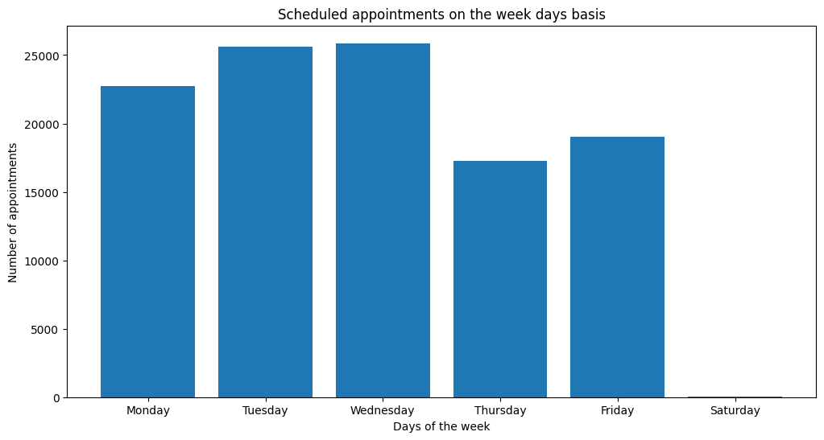

```python
# plot the results using the bar chart
labels = ['Monday', 'Tuesday', 'Wednesday', 'Thursday', 'Friday', 'Saturday']
plt.figure(figsize=(12, 6))
plt.title('Scheduled appointments on the week days basis')
plt.xlabel('Days of the week')
plt.ylabel('Number of appointments')
plt.bar(df_weekdays.index, df_weekdays.values, tick_label=labels);
```

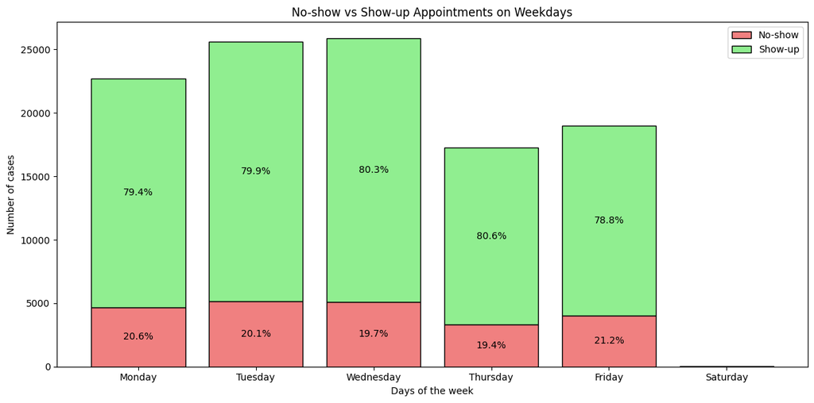

```python
# Calculate the Show-up cases by subtracting No-show cases from Total appointments
show_up_cases = df_weekdays.values - noshow_weekdays.values

# Calculate the percentage of No-show and Show-up cases
no_show_percentage = (noshow_weekdays.values / df_weekdays.values) * 100
show_up_percentage = (show_up_cases / df_weekdays.values) * 100

# Create the stacked bar plot
plt.figure(figsize=(12, 6))
plt.title('No-show vs Show-up Appointments on Weekdays')
plt.xlabel('Days of the week')
plt.ylabel('Number of cases')

# Stacked bar plot: No-show cases in red, Show-up cases in lightgreen
bars1 = plt.bar(noshow_weekdays.index, noshow_weekdays.values, label='No-show', color='lightcoral', edgecolor='black')
bars2 = plt.bar(noshow_weekdays.index, show_up_cases, bottom=noshow_weekdays.values, label='Show-up', color='lightgreen', edgecolor='black')

# Add percentage labels inside the bars
for i, (no_show, show_up, no_show_pct, show_up_pct) in enumerate(zip(noshow_weekdays.values, show_up_cases, no_show_percentage, show_up_percentage)):
    # Skip Saturday (index 5) from labeling
    if df_weekdays.index[i] == 5:  # Saturday's index is 5
        continue
    # No-show percentage label
    plt.text(i, no_show / 2, f'{no_show_pct:.1f}%', ha='center', va='center', fontsize=10, color='black')
    # Show-up percentage label
    plt.text(i, no_show + show_up_cases[i] / 2, f'{show_up_pct:.1f}%', ha='center', va='center', fontsize=10, color='black')

# Add labels, legend, and x-ticks
plt.xticks(range(6), labels=days_of_week)
plt.legend()

# Show the plot
plt.tight_layout()
plt.show()
```

## Conclusions

The factors that are important for us to know in which cases patients will not visit the scheduled appointment:

#### 1. Which age and gender groups had the most number of 'No-show' cases?

The largest number of male patients who did not come to the appointment were members of the 0-20 age group. Meanwhile, the group interval was about 20-40 for the female ones. Almost the same percentages of people from both groups missed their appointments (about 20%).

#### 3. People suffering from which illness had the most number of 'No-show' cases?

The people who suffer from hypertension did not come to the appointments most of the times compared to other provided illnesses with the noticeably large difference. It was due to the fact that many people had scheduled appointments for this illness. Thus, alcoholism was number one in terms of percentages (about 20%).

#### 4. Do the appointment days have an impact on the number of 'No-show' cases?

Almost all the days had similar proportions of “no-show” cases (about 20%). Nevertheless, Thursday was the day with the fewest cases. It is worth noting almost no hospitals scheduled the appointment for Saturdays. The median number of total “no-show” cases was about 5000 over the weekdays.

### Limitations

Due to the lack of scheduled appointment hours in the dataset, it was not possible to analyse the specific parts of the days when the patients would not come.

Moreover, the location, illness and week_day based values of no-show cases were large due to the overall value counts of the dataset.

# Project: A Simple Classification Model

## Data Preprocessing

```python
import pandas as pd
from sklearn.model_selection import train_test_split
from sklearn.preprocessing import LabelEncoder
from sklearn.impute import SimpleImputer

# Check for missing values
df.isnull().sum()

# Impute missing values for numerical columns (e.g., Age)
imputer = SimpleImputer(strategy='mean')
df['Age'] = imputer.fit_transform(df[['Age']])

# Encode categorical columns (Gender, Scholarship, Hipertension, Diabetes, Alcoholism, Handcap, SMS_received)
label_encoder = LabelEncoder()
df['Gender'] = label_encoder.fit_transform(df['Gender'])
df['Scholarship'] = label_encoder.fit_transform(df['Scholarship'])
df['Hipertension'] = label_encoder.fit_transform(df['Hipertension'])
df['Diabetes'] = label_encoder.fit_transform(df['Diabetes'])
df['Alcoholism'] = label_encoder.fit_transform(df['Alcoholism'])
df['Handcap'] = label_encoder.fit_transform(df['Handcap'])
df['SMS_received'] = label_encoder.fit_transform(df['SMS_received'])
df['No_show'] = label_encoder.fit_transform(df['No_show'])

# Convert 'ScheduledDay' and 'AppointmentDay' to datetime format
df['ScheduledDay'] = pd.to_datetime(df['ScheduledDay'])
df['AppointmentDay'] = pd.to_datetime(df['AppointmentDay'])

# Feature Engineering: Extract features from the date columns
df['ScheduledWeekday'] = df['ScheduledDay'].dt.weekday
df['ScheduledHour'] = df['ScheduledDay'].dt.hour
df['ScheduledMonth'] = df['ScheduledDay'].dt.month
df['AppointmentWeekday'] = df['AppointmentDay'].dt.weekday
df['AppointmentHour'] = df['AppointmentDay'].dt.hour

# Drop the original 'ScheduledDay' and 'AppointmentDay' columns as we extracted useful features
df = df.drop(columns=['ScheduledDay', 'AppointmentDay'])
```

## Feature Selection

The target variable is No-show (1 for no-show, 0 for show-up).

## Splitting the Data

```python
X = df.drop(columns=['No_show', 'Neighbourhood', 'PatientId', 'AppointmentID'])
y = df['No_show']

# Split the data into training and testing sets (60% train, 40% test)
X_train, X_test, y_train, y_test = train_test_split(X, y, test_size=0.4, random_state=42)
```

```python
X_train.head()
```

|  | Gender | Age | Scholarship | Hipertension | Diabetes | Alcoholism | Handcap | SMS_received | AppointmentDay_week | ScheduledWeekday | ScheduledHour | ScheduledMonth | AppointmentWeekday | AppointmentHour |
| --- | --- | --- | --- | --- | --- | --- | --- | --- | --- | --- | --- | --- | --- | --- |
| 82166 | 1 | 37.0 | 0 | 0 | 0 | 0 | 0 | 0 | 1 | 1 | 7 | 5 | 1 | 0 |
| 23506 | 1 | 57.0 | 0 | 0 | 1 | 0 | 0 | 0 | 1 | 1 | 11 | 5 | 1 | 0 |
| 1791 | 0 | 25.0 | 0 | 0 | 0 | 0 | 0 | 0 | 4 | 4 | 15 | 4 | 4 | 0 |
| 98784 | 1 | 4.0 | 1 | 0 | 0 | 0 | 0 | 0 | 4 | 4 | 7 | 6 | 4 | 0 |
| 107427 | 0 | 54.0 | 0 | 0 | 0 | 0 | 0 | 0 | 4 | 1 | 16 | 5 | 4 | 0 |

## Model Training

```python
from sklearn.ensemble import RandomForestClassifier
from sklearn.metrics import accuracy_score, confusion_matrix, classification_report
from sklearn.preprocessing import StandardScaler

scaler = StandardScaler()
X_train_scaled = scaler.fit_transform(X_train)
X_test_scaled = scaler.transform(X_test)

# Initialize the RandomForestClassifier with class_weight='balanced'
rf_classifier = RandomForestClassifier(n_estimators=100, max_depth=3, class_weight='balanced', random_state=42)

# Train the model
rf_classifier.fit(X_train, y_train)
```

```
RandomForestClassifier(class_weight='balanced', max_depth=3, random_state=42)
```

## Model Evaluation

```python
# Predict on the test set
y_pred = rf_classifier.predict(X_test)
```

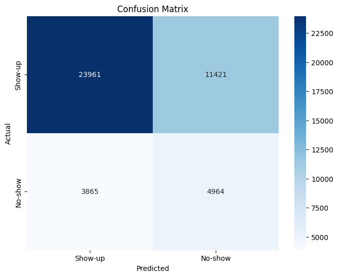

```python
import matplotlib.pyplot as plt
import seaborn as sns
from sklearn.metrics import confusion_matrix

# Compute the confusion matrix
cm = confusion_matrix(y_test, y_pred)

# Plot the confusion matrix using seaborn heatmap
plt.figure(figsize=(8, 6))
sns.heatmap(cm, annot=True, fmt='d', cmap='Blues', xticklabels=['Show-up', 'No-show'], yticklabels=['Show-up', 'No-show'])
plt.title('Confusion Matrix')
plt.xlabel('Predicted')
plt.ylabel('Actual')
plt.show()
```

```python
# Evaluate the model
print(f"Accuracy: {accuracy_score(y_test, y_pred)}")
print(f"Confusion Matrix:\n{confusion_matrix(y_test, y_pred)}")
print(f"Classification Report:\n{classification_report(y_test, y_pred)}")
```

```
Accuracy: 0.6542489425708534
Confusion Matrix:
[[23961 11421]
 [ 3865  4964]]
Classification Report:
              precision    recall  f1-score   support

           0       0.86      0.68      0.76     35382
           1       0.30      0.56      0.39      8829

    accuracy                           0.65     44211
   macro avg       0.58      0.62      0.58     44211
weighted avg       0.75      0.65      0.69     44211
```

The accuracy is low due to the fact that this dataset is imbalanced.